# PUBPOL542: Computational Thinking for Governance Analytics

## Professor Jose Manuel Magallanes

### Hanna Peterson, MPA Candidate at the Evans School of Public Policy of Governance

## Introduction to R

The following code reads your team’s final dataset from the link provided. It will also define the final data as CSV.

```r
linkcsv="https://github.com/ComputationalThinkingGroup5/Merge/raw/master/MergedData.csv"
FinalData=read.csv(linkcsv)
```

You can view the data types in your dataset using the following str() code:

```r
str(FinalData)
```

```
## 'data.frame':    162 obs. of  4 variables:
##  $ country            : chr  "Cambodia" "Niger" "Laos" "Malta" ...
##  $ percentunemployment: num  0.3 0.3 0.7 0.78 0.8 0.99 1 1.7 1.8 2 ...
##  $ pct_GDP_exp        : num  2.2 3.5 2.9 4.8 4.8 4.1 2.9 4.5 2.8 2.7 ...
##  $ percentbirthrate   : num  1.34 3.65 1.46 0.75 -0.29 0.26 3.36 1.67 2.31 0.79 ...
```

The following code will show you the names of the variables in your dataset.

```r
names(FinalData)
```

```
## [1] "country"             "percentunemployment" "pct_GDP_exp"
## [4] "percentbirthrate"
```

Determine the value of a cell by typing the indexes of where it is located:

```r
FinalData[2,3]
```

```
## [1] 3.5
```

The following code will display a row:

```r
FinalData[2,]
```

```
##   country percentunemployment pct_GDP_exp percentbirthrate
## 2   Niger                 0.3         3.5             3.65
```

The following code will display the specified columns, and the c() command prepares a vector of indexes.

```r
FinalData[2,c("country", "pct_GDP_exp","percentunemployment" )]
```

```
##   country pct_GDP_exp percentunemployment
## 2   Niger         3.5                 0.3
```

The following command defines the first condition as the country with the highest chosen variable, this case being the highest GDP expenditure.

```r
condition1=FinalData$pct_GDP_exp==max(FinalData$pct_GDP_exp)
FinalData[condition1,]
```

```
##    country percentunemployment pct_GDP_exp percentbirthrate
## 19    Cuba                 2.6        12.8            -0.23
```

```r
FinalData[condition1, "country"]
```

```
## [1] "Cuba"
```

```r
FinalData[FinalData$popgrowth.rate<0, 'country']
```

```
## character(0)
```

```r
shrinkingpop=FinalData[FinalData$popgrowth.rate<0,]
```

```r
shrinkingpop[shrinkingpop$percentunemployment==max(shrinkingpop$percentunemployment),]
```

```
## [1] country             percentunemployment pct_GDP_exp
## [4] percentbirthrate
## <0 rows> (or 0-length row.names)
```

```r
condition2=shrinkingpop$percentunemployment==max(shrinkingpop$percentunemployment)
shrinkingpop[condition2,]
```

```
## [1] country             percentunemployment pct_GDP_exp
## [4] percentbirthrate
## <0 rows> (or 0-length row.names)
```

```r
condition2
```

```
## logical(0)
```

Install pipes and dplyr.

```r
library(magrittr)
library(dplyr)
```

Define dfClus as the final dataset, including the specified columns. Explore the variables you will use for clustering.

```r
dfClus=FinalData[,c("percentunemployment", "percentbirthrate", "pct_GDP_exp")]
summary(dfClus)
```

```
##  percentunemployment percentbirthrate   pct_GDP_exp
##  Min.   : 0.300      Min.   :-2.4600   Min.   : 1.200
##  1st Qu.: 3.705      1st Qu.: 0.3050   1st Qu.: 3.200
##  Median : 6.525      Median : 0.8300   Median : 4.350
##  Mean   : 9.609      Mean   : 0.9519   Mean   : 4.474
##  3rd Qu.:10.725      3rd Qu.: 1.5825   3rd Qu.: 5.375
##  Max.   :77.000      Max.   : 3.6500   Max.   :12.800
```

Rescale units if needed into new variable:

```r
dfClus=scale(dfClus)
summary(dfClus)
```

```
##  percentunemployment percentbirthrate   pct_GDP_exp
##  Min.   :-0.9083     Min.   :-3.3149   Min.   :-1.85867
##  1st Qu.:-0.5761     1st Qu.:-0.6285   1st Qu.:-0.72328
##  Median :-0.3009     Median :-0.1184   Median :-0.07044
##  Mean   : 0.0000     Mean   : 0.0000   Mean   : 0.00000
##  3rd Qu.: 0.1089     3rd Qu.: 0.6127   3rd Qu.: 0.51145
##  Max.   : 6.5756     Max.   : 2.6215   Max.   : 4.72658
```

## R for Clustering

```r
link='https://github.com/ComputationalThinkingGroup5/Merge/raw/master/MergedData.csv'
myFile=url(link)
fromPy=read.csv(file=myFile)
row.names(fromPy)=NULL
```

Rename subset indexes and verify what your input is:

```r
row.names(dfClus)=fromPy$country
head(dfClus)
```

```
##          percentunemployment percentbirthrate pct_GDP_exp
## Cambodia          -0.9082903        0.3771237  -1.2909781
## Niger             -0.9082903        2.6215132  -0.5529760
## Laos              -0.8692609        0.4937153  -0.8935924
## Malta             -0.8614550       -0.1961187   0.1850262
## Belarus           -0.8595035       -1.2065798   0.1850262
## Thailand          -0.8409645       -0.6722013  -0.2123596
```

Set random seed: this number must correspond with any group members’ seeds. This ensures replicability of results.

```r
set.seed(999)
```

Decide distance method and compute distance matrix:

```r
library(cluster)
dfClus_D=cluster::daisy(x=dfClus)
```

Partitioning Technique 1. Apply function: you need to indicate the amount of clusters required

```r
NumCluster=4
res.pam=pam(x=dfClus_D,
            k= NumCluster,
            cluster.only = F)
```

2. Clustering results: 2.1 Add results to original data frame:

```r
fromPy$pam=as.factor(res.pam$clustering)
```

2.2 Query data frame as needed: Example 1:

```r
fromPy[fromPy$pam==1, 'country']
```

```
##  [1] "Cambodia"                 "Niger"
##  [3] "Laos"                     "Benin"
##  [5] "Vanuatu"                  "Madagascar"
##  [7] "Macau"                    "Monaco"
##  [9] "Singapore"                "Guatemala"
## [11] "Liechtenstein"            "Papua New Guinea"
## [13] "Guinea"                   "Rwanda"
## [15] "Liberia"                  "British Virgin Islands"
## [17] "Seychelles"               "Vietnam"
## [19] "Malaysia"                 "Mexico"
## [21] "Bahrain"                  "Burma"
## [23] "Cameroon"                 "Bangladesh"
## [25] "Saint Kitts and Nevis"    "Kazakhstan"
## [27] "Sri Lanka"                "Ireland"
## [29] "Azerbaijan"               "Samoa"
```

[output cut: 16 more lines]

Example 2:

```r
fromPy[fromPy$country=="Peru", 'pam']
```

```
## [1] 1
## Levels: 1 2 3 4
```

2.2 Report: table of clusters

```r
table(fromPy$pam)
```

```
##
##  1  2  3  4
## 61 41 42 18
```

3. Evaluate Results 3.1 Report: average silhouettes

```r
library(factoextra)
```

```
##   cluster size ave.sil.width
## 1       1   61          0.27
## 2       2   41          0.24
## 3       3   42          0.40
## 4       4   18          0.28
```

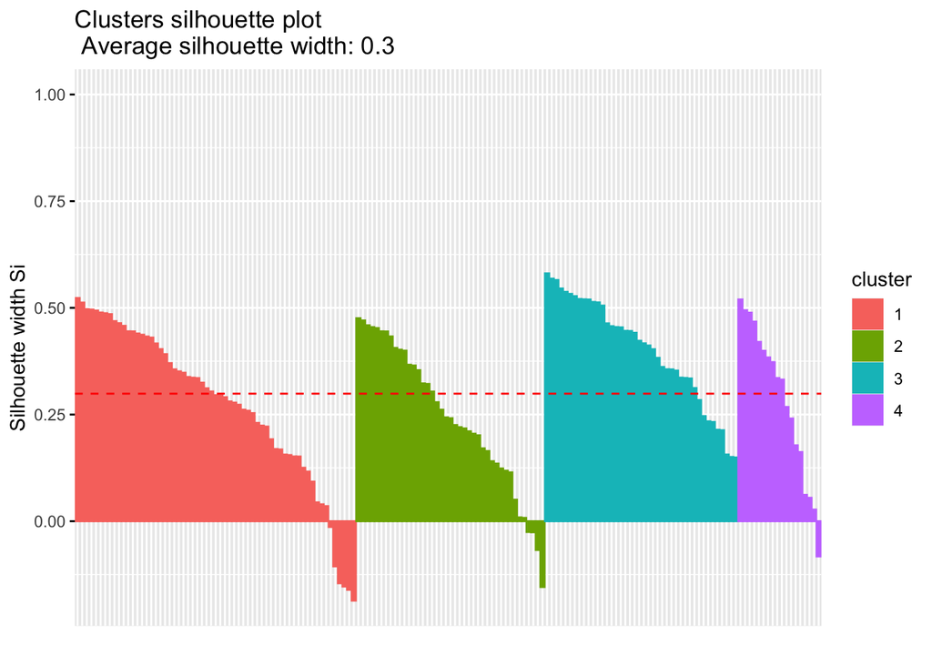

```r
fviz_silhouette(res.pam)
```

3.2 Detecting Anomalies: a. Save individual silhouettes:

```r
pamEval=data.frame(res.pam$silinfo$widths)
head(pamEval)
```

```
##                          cluster neighbor sil_width
## British Virgin Islands         1        3 0.5230789
## Pakistan                       1        2 0.5123383
## Rwanda                         1        2 0.4969379
## Comoros                        1        3 0.4960402
## Turks and Caicos Islands       1        2 0.4935898
## Guatemala                      1        3 0.4890850
```

2. Request negative silhouettes: these are the ones which are poorly clustered.

```r
pamEval[pamEval$sil_width<0,]
```

```
##                cluster neighbor   sil_width
## San Marino           1        3 -0.01356122
## Grenada              1        3 -0.10578269
## Turkey               1        3 -0.14540630
## Saint Lucia          1        3 -0.15309505
## Seychelles           1        3 -0.16069755
## Samoa                1        3 -0.18609387
## United Kingdom       2        3 -0.02530168
## Malta                2        3 -0.02585179
## Colombia             2        1 -0.06746643
## France               2        3 -0.15413921
## Zambia               4        1 -0.08251775
```

Hierarchizing: agglomerative 1. Apply function:

```r
library(factoextra)

res.agnes=hcut(dfClus_D,
               k= NumCluster, isdiss=T,
               hc_func='agnes',
               hc_method = "ward.D2")
```

2. Clustering Results: 2.1 Add results to original data frame:

```r
fromPy$agn=as.factor(res.agnes$cluster)
```

2.2 Query data frame as needed: Example 1:

```r
fromPy[fromPy$agn==1, 'country']
```

```
##  [1] "Cambodia"                 "Niger"
##  [3] "Laos"                     "Benin"
##  [5] "Vanuatu"                  "Madagascar"
##  [7] "Guatemala"                "Papua New Guinea"
##  [9] "Guinea"                   "Rwanda"
## [11] "Liberia"                  "British Virgin Islands"
## [13] "Cameroon"                 "Luxembourg"
## [15] "Pakistan"                 "Angola"
## [17] "Brunei"                   "Central African Republic"
## [19] "Togo"                     "Mali"
## [21] "Cote d'Ivoire"            "Uganda"
## [23] "Turks and Caicos Islands" "Mauritania"
## [25] "Tanzania"                 "Ghana"
## [27] "Zambia"
```

Example 2:

```r
fromPy[fromPy$country=="Peru",'agn']
```

```
## [1] 3
## Levels: 1 2 3 4
```

2.2 Report: Table of Clusters Reporting results:

```r
table(fromPy$agn)
```

```
##
##  1  2  3  4
## 27 47 69 19
```

3. Evaluate Results 3.1a Report: Dendogram

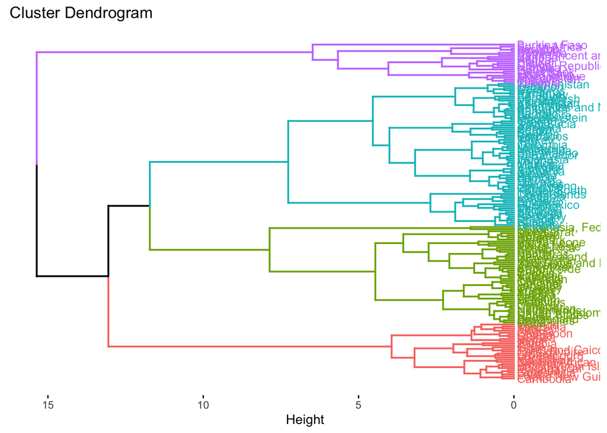

```r
fviz_dend(res.agnes,k=NumCluster, cex = 0.7, horiz= T)
```

3.1b Report: Average silhouettes

```
##   cluster size ave.sil.width
## 1       1   27          0.41
## 2       2   47          0.27
## 3       3   69          0.27
## 4       4   19          0.21
```

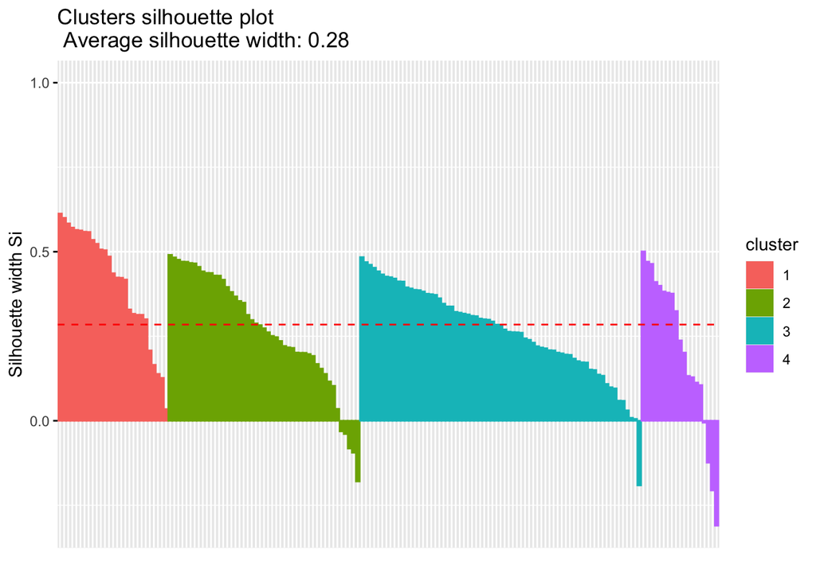

```r
library(factoextra)
fviz_silhouette(res.agnes)
```

3.2 Report: Detecting Anomalies a. Saving silhouettes:

```r
agnEval=data.frame(res.agnes$silinfo$widths)
head(agnEval)
```

```
##            cluster neighbor sil_width
## Cameroon         1        3 0.6128457
## Liberia          1        3 0.6001858
## Guinea           1        3 0.5836463
## Tanzania         1        3 0.5713340
## Madagascar       1        3 0.5645315
## Angola           1        2 0.5629379
```

2. Request negative silhouettes:

```r
agnEval[agnEval$sil_width<0,]
```

```
##                                  cluster neighbor   sil_width
## Jamaica                                2        3 -0.03132904
## Uruguay                                2        3 -0.03924979
## Curacao                                2        3 -0.08221345
## Mauritius                              2        3 -0.09456060
## Seychelles                             2        3 -0.17948812
## Comoros                                3        1 -0.19108640
## Malawi                                 4        1 -0.00562688
## Dominica                               4        2 -0.12398589
## Ethiopia                               4        1 -0.20616070
## Saint Vincent and the Grenadines       4        2 -0.31033947
```

Hierarchizing: divisive 1. Apply function: you need to indicate amount of clusters required. Install factoextra.

```r
library(factoextra)

res.diana= hcut(dfClus_D, k = NumCluster,
                hc_func='diana',
                hc_method = "ward.D")
```

2. Clustering Results: 2.1 Adding results to original data frame:

```r
fromPy$dia=as.factor(res.diana$cluster)
```

2.2 Query data frame as needed: Example 1:

```r
fromPy[fromPy$dia==1, 'country']
```

```
##  [1] "Cambodia"                 "Niger"
##  [3] "Laos"                     "Benin"
##  [5] "Vanuatu"                  "Madagascar"
##  [7] "Macau"                    "Monaco"
##  [9] "Singapore"                "Guatemala"
## [11] "Japan"                    "Liechtenstein"
## [13] "Papua New Guinea"         "Guinea"
## [15] "Rwanda"                   "Liberia"
## [17] "British Virgin Islands"   "Hong Kong"
## [19] "Romania"                  "Vietnam"
## [21] "Malaysia"                 "Mexico"
## [23] "Bahrain"                  "Andorra"
## [25] "Burma"                    "Cameroon"
## [27] "Bangladesh"               "Fiji"
## [29] "Saint Kitts and Nevis"    "Kazakhstan"
```

[output cut: 20 more lines]

Example 2:

```r
fromPy[fromPy$country=="Peru", 'dia']
```

```
## [1] 1
## Levels: 1 2 3 4
```

2.3 Report: Table of Clusters Reporting results:

```r
table(fromPy$dia)
```

```
##
##  1  2  3  4
## 69 74 18  1
```

Evaluating Results: 3.1a Report: Dendogram

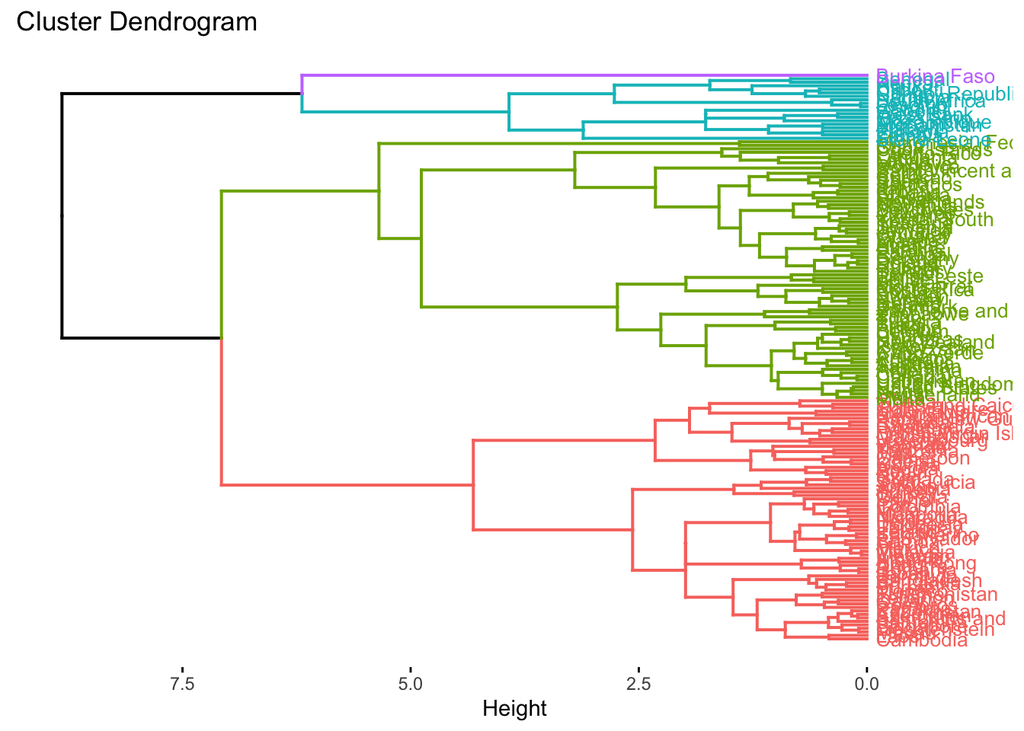

```r
fviz_dend(res.diana, k=NumCluster, cex = 0.7, horiz = T)
```

3.1b Report: Average silhouettes. Install factoextra.

```
##   cluster size ave.sil.width
## 1       1   69          0.30
## 2       2   74          0.26
## 3       3   18          0.33
## 4       4    1          0.00
```

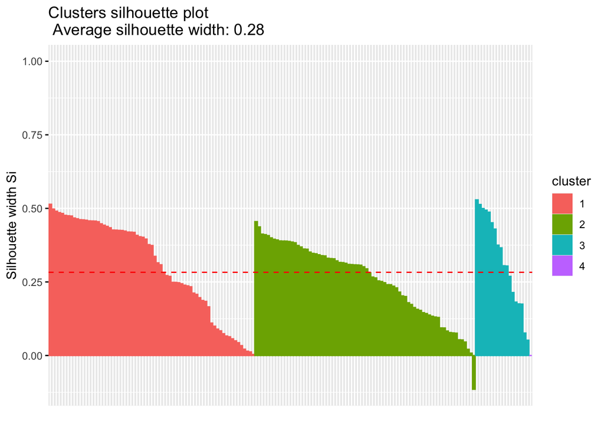

```r
library(factoextra)
fviz_silhouette(res.diana)
```

3.2 Report: Detecting anomolies Saving silhouettes:

```r
diaEval=data.frame(res.diana$silinfo$widths)
head(diaEval)
```

```
##                        cluster neighbor sil_width
## Comoros                      1        2 0.5140884
## Papua New Guinea             1        2 0.4977189
## British Virgin Islands       1        2 0.4905131
## Qatar                        1        2 0.4855992
## Pakistan                     1        2 0.4827332
## Cambodia                     1        2 0.4764699
```

Request negative silhouettes:

```r
diaEval[diaEval$sil_width<0,]
```

```
##      cluster neighbor sil_width
## Togo       2        1  -0.11473
```

Density-based clustering Input the distance and the minimal number of neighbors that form a cluster.

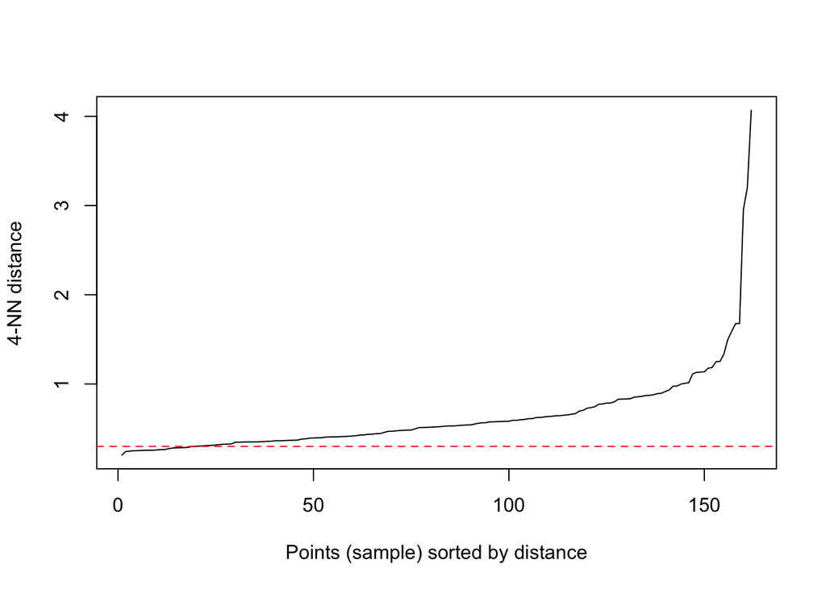

```r
library(dbscan)
minNeighs=4
kNNdistplot(dfClus_D, k = minNeighs)
abline(h=0.3, col = "red", lty=2)
```

Format the table

```r
distance=0.3
res.db=dbscan::dbscan(dfClus_D,
                      eps=distance,
                      minPts=minNeighs)
```

Report: How many clusters were produced, and how many outliers are there?

```r
res.db
```

```
## DBSCAN clustering for 162 objects.
## Parameters: eps = 0.3, minPts = 4
## The clustering contains 7 cluster(s) and 113 noise points.
##
##   0   1   2   3   4   5   6   7
## 113   6   9   9   7  10   4   4
##
## Available fields: cluster, eps, minPts
```

Save results:

```r
fromPy$db=as.factor(res.db$cluster)
```

Comparing clustering Prepare a bidimensional map:

```r
projectedData=cmdscale(dfClus_D, k=2)
fromPy$dim1 = projectedData[,1]
fromPy$dim2 = projectedData[,2]
```

See the data plotted/mapped:

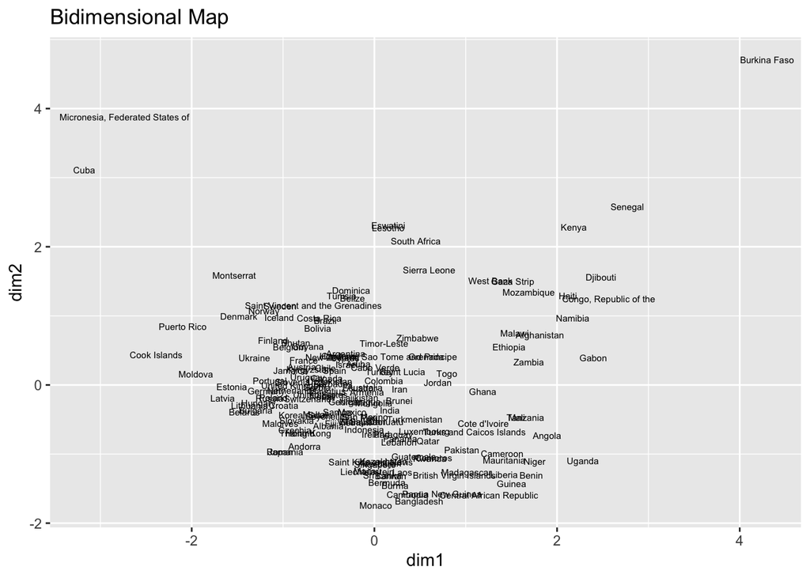

```r
base= ggplot(data=fromPy,
             aes(x=dim1, y=dim2,
                 label=country))
base + labs(title= "Bidimensional Map") + geom_text(size=2)
```

```r
Cluster1=base + labs(title = "Cluster1") + geom_point(size = 2,
                                                aes(color=agn),
                                                show.legend = F)
```

Plot results from hierarchial AGNES:

```r
Cluster2=base + labs(title = "Cluster2") + geom_point(size=2,
                                                  aes(color=agn),
                                                  show.legend = F)
```

Plot results from hierarchical DIANA:

```r
Cluster3=base + labs(title = "Cluster3") + geom_point(size=2,
                                                  aes(color=dia),
                                                  show.legend = F)
```

Visually compare the data.

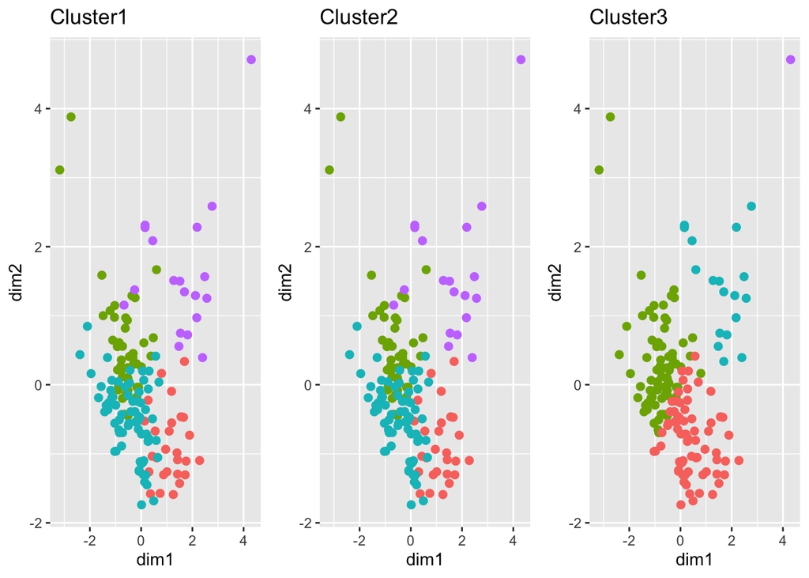

```r
library(ggpubr)
ggarrange(Cluster1, Cluster2, Cluster3, ncol = 3)
```

Plot results:

```r
dbPlot = base + labs(title = "DBSCAN") + geom_point(aes(color=db),
                                                    show.legend = T)
```

Annotate data:

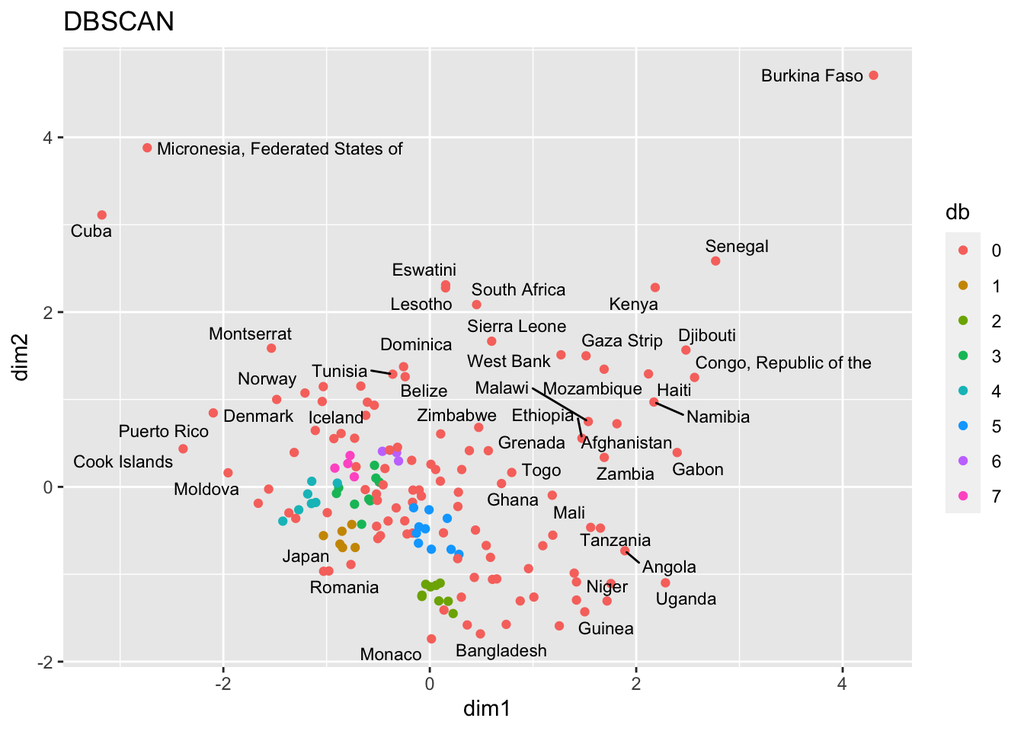

```r
library(ggrepel)
dbPlot + geom_text_repel(size=3, aes(label=country))
```

Annotate outliers of the dataset:

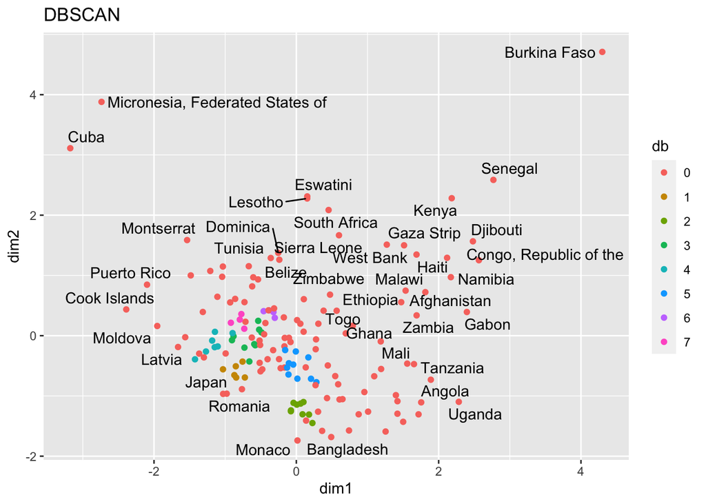

```r
LABEL=ifelse(fromPy$db==0, fromPy$country, "")

dbPlot + geom_text_repel(aes(label=LABEL))
```